# Milestone Report Rubric

Daniel Sananez

Friday, December 11, 2015

### Summary

The goal in this document is to display that I’ve gotten used to working with the data and that I’m on track to create my prediction algorithm. Here, I will be describing my exploratory analysis and my future goals for my app. I would like to add that, as I explained in [this forum post](https://class.coursera.org/dsscapstone-006/forum/thread?thread_id=34), I’ll be using a sample of the data for the advanced part of the analysis.

### Data

For this project, the [datasaet](https://d396qusza40orc.cloudfront.net/dsscapstone/dataset/Coursera-SwiftKey.zip) consists in 3 text files containing a combination of english sentences. Each file represents the source of the texts (blogs, news and tweets).

I used fuctions like `dir.create()`, `download.file()` and `unzip()` to download and unzip the data in a specefic folder.

### Basic Exploratory Analysis

In my Basic Exploratory Analysis, I’ll be using the whole dataset. Here I’ll be doing some word, line, and character counts for each of the 3 files.

```
##        Line Count Word Count Character Count Avg. Word/Line Avg Char/Word
## Blogs      899288   39121566       206824505       43.50282      5.286713
## News      1010242   36721104       203223159       36.34882      5.534233
## Tweets    2360148   32793432       162096241       13.89465      4.942948
```

Here we can see some interesting facts about the datasets. First, the blogs have the lowest amount of lines (899,288.0) but the highest amount of words (39,121,566.0). This is because of the high average words-per-lines blogs have (43.5). On the other hand, tweets suffers the opposite effect: most lines (2,360,148.0) with least words (32,793,432.0). This one is more obvious because of the characters limit tweets have (140 characters), which drops the average words-per-tweet to 13.9 (68.1% lower than blog’s average word per line). Also, we can see that tweets’ dataset have the lowest character-per-word average (4.9). Do people use shorter words in tweets to save characters?

### Advanced Exploratory Analysis

As I already mentioned, I used a `sample()` of the dataset for this part of the analysis. However, before sampling the data I did some [Normalization](https://en.wikipedia.org/wiki/Text_normalization) and Tokenization using `library(tm)` package.

#### Wordcloud

I used a combination of the 3 datasets samples to plot a [wordcloud](https://cran.r-project.org/web/packages/wordcloud/wordcloud.pdf) unsing `library(wordcloud)` package. Here is what I got:

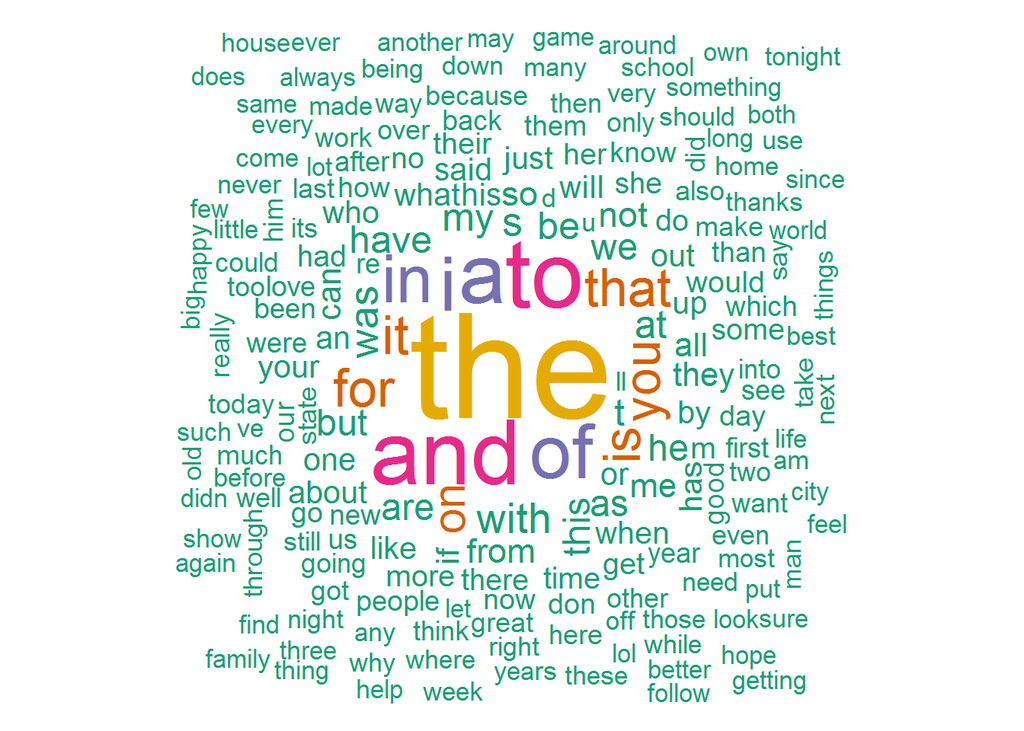

The wordcloud seems very accurate. As expected, we can see very common english words on top of the rank. Playing with the code, I could determine that the top 125 words in my sample accounts for 50.53% of the frequencies. Interesting fact.

#### N-grams

Now, lets take a look to the top [n-grams](https://en.wikipedia.org/wiki/N-gram) I found in my sample. I did bi-grams, tri-grmas and four-grams, let’s see the results.

**Bi-grams**

My top 15 bi-grams are:

```
## bigram
##   of the   in the     it s      i m   to the  for the   on the    don t
##    10693    10237     5709     5451     5360     5093     4817     4140
##    to be   at the  and the     in a with the    and i     is a
##     4015     3537     3173     2968     2676     2586     2519
```

**Tri-grams**

My top 15 tri-grams are:

```
## trigram
##        i don t     one of the       a lot of         it s a thanks for the
##           1431            861            757            648            627
##        i can t        i m not     don t know        to be a       i didn t
##            612            534            456            453            450
##       it s not     can t wait    going to be      you don t     out of the
##            436            429            424            414            384
```

**Four-grams**

My top 15 four-grams are:

```
## fourgram
##          i m going to          i don t know         can t wait to
##                   293                   275                   242
##         i don t think       the rest of the        the end of the
##                   202                   187                   186
##         at the end of thanks for the follow    for the first time
##                   176                   169                   164
##         don t want to      at the same time          i don t want
##                   161                   127                   122
##       one of the most          i can t wait         is one of the
##                   117                   112                   112
```

Doing this analysis I could realize my normalization needs a bit of extra tuning. I’ll need to change letters like “t”, “d”, “s” and “m” for “not”, “had”, “is” and “am”, respectively. Also, some words like “don”(do) need changes.

### Next Steps

In order to continue working on my prediction app, I want to combine from bi-grams to four-grams in a complex model. I would like to also add a [Linear Interpolation](https://en.wikipedia.org/wiki/Linear_interpolation) Smoothing, but I need to do some research before. Later on, I’ll be adding the proffanity filter and fixing the normalizations details that came out of this analysis.